# Research Method of Data Science

## Week 11: Bivariate Analysis and Inference

### Iegor Vyshnevskyi, Ph.D.

### Sogang University

### November 10/12, 2026

# Tuesday agenda

**Focus:** choose evidence that fits the question and explain what it supports. Companion notebook: **W11_RMDS_Inference_Lab.ipynb**

1Comparing two variables with real evidence

2Sampling variation and confidence intervals

3Tests, null models, and p-values

4Effect size and substantive importance

5Evidence choices for research questions

6Preparation for Thursday

# Description and inference

## Description

A graph or table summarises the records you observed.

## Inference

The analysis asks what those records support about a defined target under explicit assumptions.

**PAIR DISCUSSION · 3 MIN**  
If two groups have different average earnings, what else must you know before claiming that a programme worked?

**Key distinction:** description stays with the observed records; inference connects those records to a target beyond the sample.

# 1. Bivariate questions have different forms

**Group + number**Training group and earningsGroup summaries and distributions

**Number + number**Earnings in two baseline yearsScatterplot and association measure

**Group + binary**Training group and positive earningsCounts, proportions, and percentage-point gap

Variable types help choose the comparison. Study design determines the claim.

**First step:** name the type of each variable. That decision narrows the sensible summaries, plots, and methods.

# Study question and observed earnings

## National Supported Work study

**Primary question:** How do mean 1978 real earnings differ between the training and control groups?

The analysis uses the source-dollar scale. The sample does not represent all workers or current monetary values.

## Observed participants

**185** training participants

**260** controls

Zeros are valid earnings observations, not missing values.

**6,349**Training mean

**4,555**Control mean

**1,794**Observed mean gap

**445**Total observed N

The 1,794-dollar gap is an estimate from this sample. Its uncertainty and the study design determine how far the claim can extend.

# The distributions need inspection

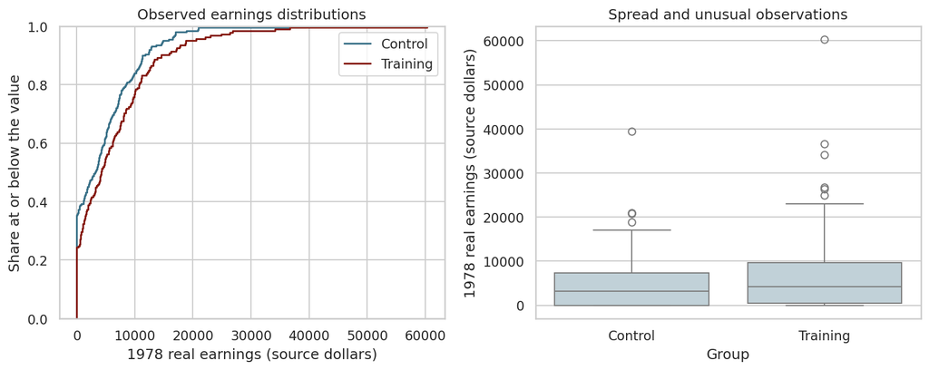

Which features could affect a mean comparison? Discuss for one minute.

**How to read:** the ECDF shows the share at or below each earnings value; the boxplot highlights centre, spread, and unusual observations.

# 2. Sampling variation and confidence intervals

The next question is why a reasonable estimate changes from sample to sample and how an interval expresses that uncertainty.

# Standard deviation and standard error

## SD · individuals

Standard deviation describes how much individual outcomes vary.

## SE · estimates

Standard error describes how an estimator varies across repeated samples under its model.

**Independent-group mean contrast:** SE = sqrt(SD₁² / n₁ + SD₀² / n₀)

More observations can reduce SE without making individuals more alike.

**Memory aid:** SD describes variation among people; SE describes the precision of an estimate.

# A teaching experiment shows sampling variation

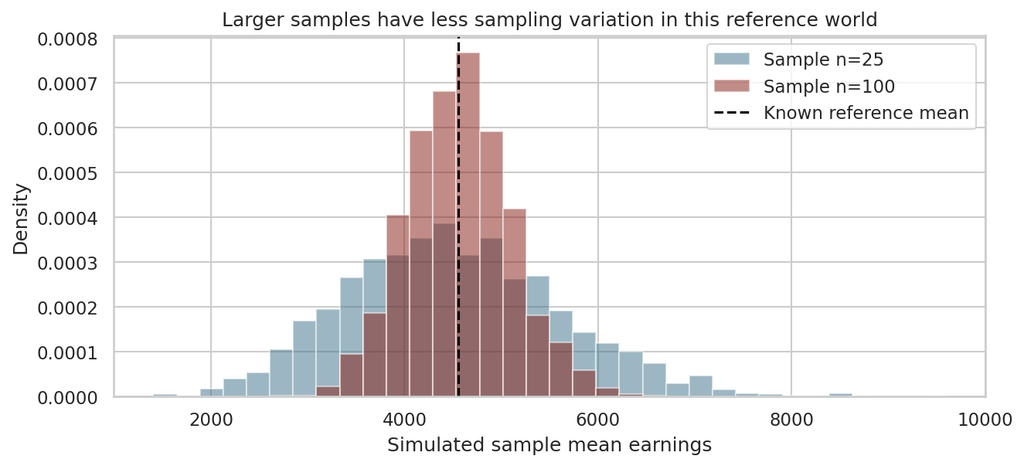

Simulated draws from the real control earnings used as a known reference distribution.

The narrower distribution for n = 100 means that larger samples produce more stable means in this reference world.

# Sampling challenge — pairs, 3 minutes

The reference distribution stays the same.

Sample size increases from **25 to 100**.

1. Predict the change in the spread of sample means.
2. Does increasing the sample remove systematic selection bias?
3. Are 2,000 simulated samples the same as observing 2,000 new participants?

Changing sample size changes random sampling variation. It does not automatically correct biased selection or poor measurement.

# Confidence intervals concern estimates

**Interval = estimate ± critical value × SE**

## Repeated procedure

Under its assumptions, a 95% procedure covers the fixed target in approximately 95% of repeated studies.

## Observed interval

Report the range, target, method, and assumptions for the interval you calculated.

The interval does not describe individual earnings and does not assign a probability to the fixed target.

A 95% confidence level describes the long-run success rate of the method, not the probability that this one fixed interval is correct.

# The real mean difference with uncertainty

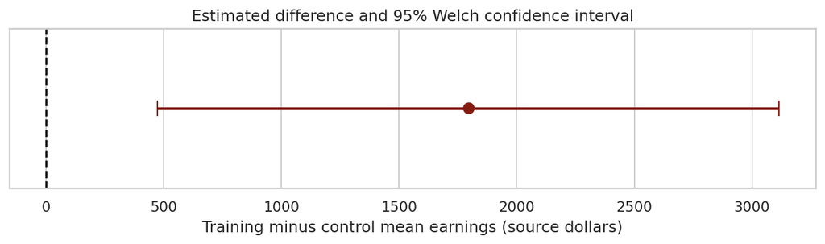

Estimate: 1,794. Approximate 95% Welch interval: 474 to 3,115 source dollars.

**How to read:** the dot is the estimated mean gap; the horizontal line shows values reasonably compatible with the data and model.

# Repeated intervals illustrate coverage

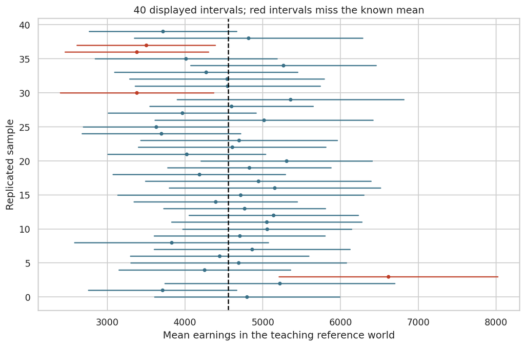

The dashed line is the known mean of the teaching reference distribution.

Each horizontal line comes from a new simulated sample. Most cross the known target, while a small number miss it.

# Interval interpretation — pairs, 4 minutes

Which claims follow from the earnings interval?

A. Most participants gained between 474 and 3,115 dollars.

B. The estimated mean contrast is positive, with substantial uncertainty about its size.

C. The programme is proven worthwhile in every country.

Explain your choice and repair one incorrect claim.

Keep the target clear: this interval concerns a group mean difference, not the earnings change of every participant.

# Bootstrap resampling estimates uncertainty

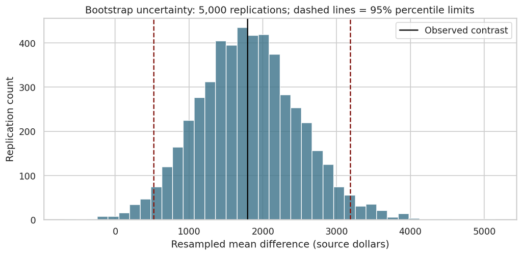

Resample people within each group with replacement. The contrast varies around the observed estimate.

Bootstrap samples are generated from the observed groups, so the distribution remains centred near the observed contrast rather than zero.

# 3. Tests, null models and p-values

Testing asks how unusual the observed statistic would be if a specified null model generated the data.

# Hypothesis test and p-value

## The question

**Null:** the target mean contrast equals zero.

**Alternative:** the contrast differs from zero.

The two-sided Welch test compares the standardized observed gap with its null reference.

## The evidence

**Two-sided p = 0.0079**

Under the null model, this is the probability of a statistic at least as extreme as the observed one.

The p-value does not give the probability that the null is true, the size or importance of the contrast, or proof that bias is absent.

A small p-value describes tension between the data and the null model. It does not by itself establish causality or practical value.

# A null reference uses a different operation

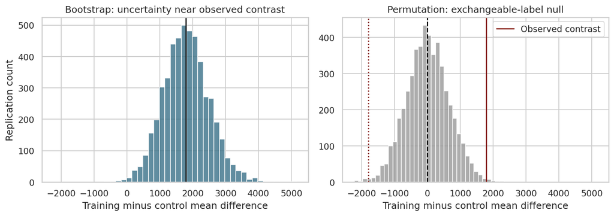

Bootstrap: uncertainty around the contrast. Shuffled labels: an exchangeable-label null reference.

**Compare the centres:** bootstrap contrasts cluster near the estimate; shuffled-label contrasts cluster near the null value of zero.

# A result is more than a threshold

For the same two-sided Welch procedure:

The **95% interval excludes zero**, and **p < 0.05**.

That is a statistical conclusion under the procedure’s assumptions.

Report the estimate and interval alongside p. A larger p-value would not prove equality or no meaningful effect.

Different methods can yield different intervals or p-values.

Report the estimated size and uncertainty even when p is below 0.05; the threshold alone cannot show whether the result matters.

# 4. Effect size and substantive importance

Statistical evidence concerns uncertainty. Substantive importance requires context, units, costs, and a justified benchmark.

# Size, precision and substantive importance

**1,794**Mean contrast

**671**Standard error

**474–3,115**95% interval

**0.273**Cohen’s d

## Statistical evidence

Two-sided Welch p = **0.0079**

Observed sample: 185 training and 260 control participants.

## Substantive judgement

Compare the estimate with a justified benchmark, programme costs, the price basis, and the research setting.

Outcome: 1978 real earnings on the source-dollar scale. Report the estimate and uncertainty, not a software dump.

The raw mean contrast answers 'how many source dollars?'; Cohen's d expresses the same gap relative to within-group variation.

# Judgement challenge — pairs, 4 minutes

Suppose **2,000 source dollars** is an illustrative minimum worthwhile mean gain.

1. Is the estimated contrast above that benchmark?
2. Does the confidence interval establish a gain of at least 2,000?
3. What else would you need before judging programme value?

The benchmark is for discussion; it is not a measured programme cost.

An estimate can be close to a benchmark while the interval still includes values on both sides of it.

# 5. Choosing evidence for the research question

The method should follow the variables, unit of analysis, dependence structure, and claim, rather than habit or software availability.

# Methods follow the variables and design

**Independent means**Difference and Welch interval/testCheck units and independence

**Repeated people**Within-person differencesPairing does not make change causal

**Two numbers**Scatterplot and Pearson/SpearmanCheck shape, unusual values, dependence

**Two proportions**Counts and percentage-point gapCheck sample size and outcome definition

Repeated country-years and clusters need methods that respect dependence.

Two datasets with similar columns may require different methods when observations are paired, clustered, weighted, or repeated over time.

# Two applications answer different questions

## Numerical association

Among 260 controls, compare baseline earnings in 1974 and 1975.

**Pearson r = 0.675**  
**Spearman ρ = 0.767**

Inspect the shape, tied zeros, and unusual values before interpreting the association.

## Binary outcome

Positive 1978 earnings: **64.6%** control and **75.7%** training.

**Gap = 11.1 percentage points**  
95% interval: 2.6 to 19.5 points.

Positive earnings do not directly measure employment status.

The association is observational. Dichotomizing earnings changes the question and discards information about earnings magnitude.

Correlation retains earnings magnitude; a binary positive-earnings outcome asks a simpler question but discards how much people earned.

# Evidence choice — pairs, 2 minutes

Choose a starting approach and one limitation:

1. AI reliance and critical-thinking scores from one survey.
2. Changes in the same students’ scores over time.
3. Annual poverty observations repeated within provinces.

Explain what would be wrong with treating every row as an independent, representative observation.

For each example, identify the observational unit and ask whether rows can reasonably be treated as independent.

# 6. Preparation for Thursday

Bring your current question and a description of your evidence.

Open **W11_RMDS_Inference_Lab.ipynb** in Colab or Jupyter.

The real source data are embedded. No separate download is needed.

You will compare estimates, resampling distributions and interpretations, then select an appropriate form of evidence for your project.

The lab emphasizes interpretation. The code is supplied so that class time can focus on evidence, assumptions, and claims.

# Thursday — Simulation and inference lab

The lab turns the lecture concepts into one reproducible analysis using real records and transparent simulations.

# Thursday agenda

1Inspect the study and estimate the contrast

2Simulate sampling variation and interval coverage

3Compare bootstrap and null-reference distributions

4Apply a method to a different question

5Write a bounded result and project evidence plan

Work individually. Use pairs to check interpretations.

Move through the notebook in order: later sections reuse the estimate, groups, and interpretation established at the beginning.

# Lab steps 1–2: source, estimate, and interval

10 MIN · NOTEBOOK 0–1

## Source and first evidence

1. Save a copy and run setup.
2. Check the source and design notes.
3. Inspect the grouped table and distributions.
4. Complete Activity A.

**Check:** 445 observed participants.

10 MIN · NOTEBOOK 2

## Estimate and interval

1. Run the Welch comparison.
2. Identify the estimate, units, sample sizes, SE, interval, and p-value.
3. Complete Activity B using the 2,000-dollar benchmark.

Before interpreting any output, verify the unit, group definitions, outcome units, and direction of the contrast.

# Lab steps 3–4: sampling and bootstrap uncertainty

10 MIN · NOTEBOOK 3

## Sampling and coverage

1. Predict how sample size changes the spread of sample means.
2. Predict whether every 95% interval covers the reference mean.
3. Run the simulation and complete Activity C.

Explain what the teaching reference world represents.

12 MIN · NOTEBOOK 4

## Bootstrap uncertainty

1. Resample within each group.
2. Compare bootstrap and Welch intervals.
3. Explain the centre of the bootstrap distribution.
4. Complete Activity D.

Keep observed participants, sample size, and replication count distinct.

Keep three quantities separate: observed participants, observations in each resample, and the number of simulation replications.

# Lab steps 5–6: null reference and application

10 MIN · NOTEBOOK 5

## Null-reference experiment

1. Predict the centre after shuffling labels.
2. Compare the null reference with the bootstrap.
3. Explain exchangeability and the design boundary.
4. Complete Activity E in words.

10 MIN · NOTEBOOK 6

## Choose one application

**A:** baseline earnings association and scatterplot.

**B:** positive-earnings counts, interval, and percentage-point gap.

Complete one response and state its main inferential limitation.

The null-reference exercise addresses compatibility with zero; the application exercise changes the research question and evidence type.

# Lab steps 7–8: result, project choice, and submission

10 MIN · NOTEBOOK 7

## Result and project choice

Write an **80–120 word** primary-result paragraph.

For your project, identify the variables, unit, claim, suitable evidence, dependence, and limits.

Check one sentence with a partner.

3 MIN · SUBMIT

## Save and submit

1. Save the completed notebook.
2. Download the output bundle.
3. Record permitted AI assistance and verification.
4. Follow Cyber Campus instructions.

A complete result combines a numerical finding with its context, assumptions, and one honest limitation.

# Appendix — reference and stretch materials

Use these slides when students need another example, an assumption reminder, or help connecting the notebook to their projects.

# Reference: the association plot

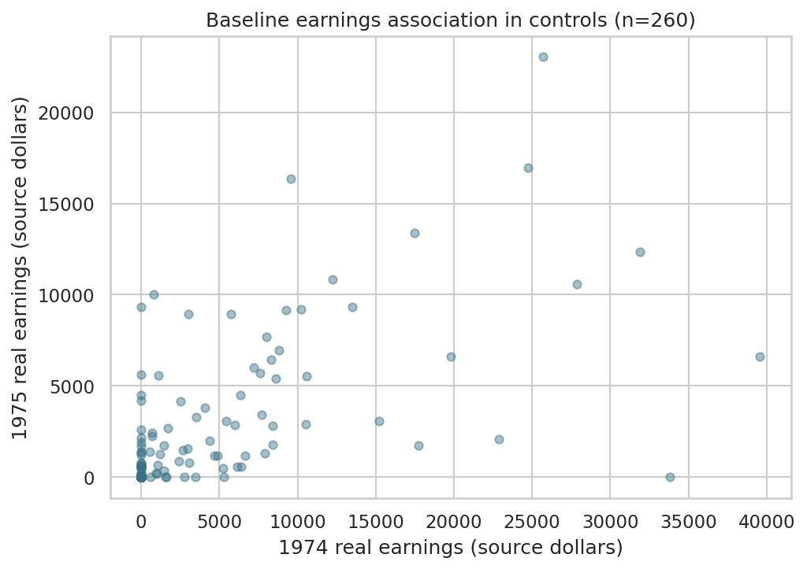

Control participants, two pre-intervention earnings variables, n = 260.

A positive pattern is visible, but tied zeros and high observations can affect correlation measures and their uncertainty.

# Reference: proportions and an interval

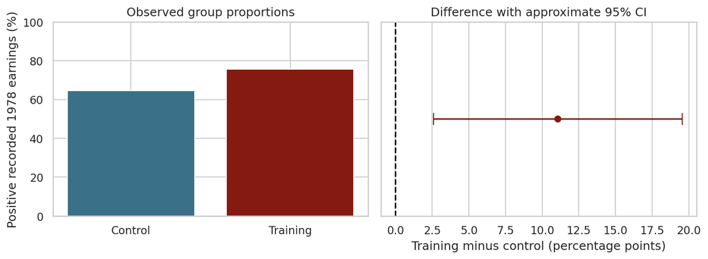

Positive recorded earnings, not a directly verified employment rate.

A percentage-point difference subtracts two proportions; it is different from a relative percentage increase.

# Reference: pairing and method assumptions

## Paired observations

When the same person supplies two measurements, analyse the **within-person difference**.

The notebook compares 1975–1978 changes within each group. A before-after change alone does not identify the training effect.

## Assumptions to check

**Welch:** independent records and an appropriate mean target.

**Bootstrap:** resampling unit matches the design.

**Permutation:** labels are exchangeable under the null.

**Association/proportions:** dependence, shape, and counts support the method.

A software function cannot validate the research design.

Correct computation starts with the correct resampling or comparison unit: person, pair, cluster, or another design-defined unit.

# Reference: a research-result checklist

A reader should find:

1. Question and study context
2. Quantity estimated and units
3. Observed sample and comparison
4. Estimate and uncertainty
5. Test result, if appropriate
6. Substantive interpretation and limitations

Report all relevant planned analyses and label exploratory work.

A reader should be able to reconstruct what was compared, what was estimated, and why the conclusion remains bounded.

# Notebook map and reusable functions

| Section / function | Purpose |
|---|---|
| 0–1 | Source verification, group table and plots |
| 2 `mean_difference()` | Welch estimate, SE, CI, p and standardized d |
| 3 | Sampling variation and coverage demonstration |
| 4 `bootstrap_difference()` | Within-group resampling and percentile interval |
| 5 `shuffle_difference()` | Exchangeable-label null and Monte Carlo p |
| 6 | Numerical association or binary comparison |
| 7–9 | Reporting, project choice, export and paired extensions |

Use the functions as transparent examples. Adapt the analysis only after checking whether your project has the same unit and design.

# Sources and software documentation

### Data and research

- [Dehejia data page and NSW files](https://users.nber.org/~rdehejia/data/.nswdata2.html)
- LaLonde (1986), *American Economic Review*, 76, 604–620
- Dehejia and Wahba (1999), *JASA*, 94, 1053–1062
- [ASA statement on p-values](https://www.amstat.org/asa/files/pdfs/p-valuestatement.pdf)

### Software documentation

- [SciPy Welch t test](https://docs.scipy.org/doc/scipy/reference/generated/scipy.stats.ttest_ind.html)
- [SciPy Pearson correlation](https://docs.scipy.org/doc/scipy/reference/generated/scipy.stats.pearsonr.html)
- [SciPy permutation methods](https://docs.scipy.org/doc/scipy/reference/generated/scipy.stats.permutation_test.html)

**PROVENANCE** Original records, retrieval details, and hashes accompany the notebook.

Research claims should remain traceable to the original data, scholarly sources, and documented statistical procedures.